# Equations

David Kahler

4/28/2021

# R Markdown with Equations in $\LaTeX$

The purpose of this document is to demonstrate the utility of R Markdown in the preparation of documents. Recently, a colleague came to me with a formatting problem: a book publisher was requiring tue use of $\LaTeX$ or MathType. I recommended $\LaTeX$ in R Markdown.

To check the rendering of equations (the TeX code is all you need to send to the publisher), make sure to add:

```r
\usepackage{amsmath}
\usepackage{isotope}
```

to your R Markdown header. The amsmath package contains most all of the $\LaTeX$ commands and the isotope package is helpful for chemical equations.

## Writing Equations

For inline equations, you start and end the $\LaTeX$ string with $. To enter a centered equation, start with:

```r
\begin{equation}
N = N_0 e^{-\lambda t}
\end{equation}
```

### Example Equations

#### 8.1

$$\begin{equation}
N = N_0 e^{-\lambda t}
\end{equation}$$

#### 8.2

$$\begin{equation}
\label{eq:8.2}
\mathrm{^{226}_{88}Ra} \rightarrow \mathrm{^{222}_{86}Rn} + \mathrm{^{4}_{2}He^{2+}} + \gamma + hv
\end{equation}$$

#### 8.3

$$\begin{equation}
\mathrm{^{228}_{88}Ra} \rightarrow \mathrm{^{228}_{89}Ac} + \mathrm{e^{-}} + \gamma + hv
\end{equation}$$

#### 8.4

$$\begin{equation}
A_n = \lambda_n N_n
\end{equation}$$

#### 8.5

$$\begin{equation}
N_n = c_{1} e^{-\lambda_1 t} + c_{2} e^{-\lambda_2 t} + c_{3} e^{-\lambda_3 t} + \ldots + c_{n} e^{-\lambda_n t}
\end{equation}$$

#### 8.6

$$\begin{equation}
c_1 = \frac{\lambda_1 \lambda_2 \ldots \lambda_{n-1}}{(\lambda_2 -\lambda_1) (\lambda_3 -\lambda_1) (\lambda_n \lambda_1)} N^{0}_{1}
\end{equation}$$

#### 8.7

$$\begin{equation}
c_2 = \frac{\lambda_1 \lambda_2 \ldots \lambda_{n-1}}{(\lambda_1 -\lambda_2) (\lambda_3 -\lambda_2) (\lambda_n \lambda_2)} N^{0}_{1}
\end{equation}$$

#### 8.8

$$\begin{equation}
c_3 = \frac{\lambda_1 \lambda_2 \ldots \lambda_{n-1}}{(\lambda_1 -\lambda_n) (\lambda_2 -\lambda_n) (\lambda_{n-1} -\lambda_n)} N^{0}_{1}
\end{equation}$$

#### 8.9

$$\begin{equation}
\log([\mathrm{^{226}Ra}]) = 1.3536 \times \log({TDS}) - 4.4513
\end{equation}$$

#### 8.10

$$\begin{equation}
\log([\mathrm{^{226}Ra}]) = 0.6521 \times \log(\mathrm{[Cl]}) - 0.8448
\end{equation}$$

#### 7.1

$$\begin{equation}
M_0 = G \bar{d} A
\end{equation}$$

#### 7.2

$$\begin{equation}
M_W = \frac{2}{3} \log_{10}M_0 - 6.03
\end{equation}$$

The original equation used a slanted fraction bar to express the two-thirds. This is not available in R Markdown. With a different TeX platform, may work as part of the xfrac package.

#### 7.3

$$\begin{equation}
M_L = \log_{10}A + 2.56 \log_{10} \Delta - 1.67
\end{equation}$$

#### 7.4

$$\begin{equation}
\log_{10} N = a - b M, M \geq M_C
\end{equation}$$

#### 7.5

$$\begin{equation}
\sigma (x) = \begin{bmatrix} \sigma_{11} & \sigma_{12} & \sigma_{13} \\ \sigma_{21} & \sigma_{22} & \sigma_{23} \\ \sigma_{31} & \sigma_{32} & \sigma_{33} \end{bmatrix}
\end{equation}$$

#### 7.6

Check prime usage:
$$\begin{equation}
S_V(z) = \int_0^{z} \rho (z^\prime) g d z^\prime
\end{equation}$$

#### 7.7

$$\begin{equation}
\sigma_n^\prime = \sigma_n - \alpha P
\end{equation}$$

#### 7.8

$$\begin{equation}
\mathrm{\bf{T}} = \mathrm{\bf{\sigma \hat{n}}}
\end{equation}$$

#### 7.9

$$\begin{equation}
\lvert \tau \rvert = C + \mu \sigma_N^\prime
\end{equation}$$

#### 7.10

$$\begin{equation}
\sigma_1 = \lbrack \sqrt{\mu^2 + 1} + \mu \rbrack^2 \sigma_3 + 2 C \lbrack \sqrt{\mu^2 + 1} + \mu \rbrack
\end{equation}$$

#### 7.11

Check *max* subscript versus superscript, check scalar product:
$$\begin{equation}
M_0^{max} = G \cdot V
\end{equation}$$

#### 7.12

$$\begin{equation}
M_{max} = M_C + \frac{1}{b} \log_{10} N
\end{equation}$$

#### 7.13

$$\begin{equation}
\Sigma = \log_{10} N - \log_{10} V + b M_C
\end{equation}$$

#### 7.14

$$\begin{equation}
M_{max} = \frac{1}{b} (\Sigma + \log_{10} V)
\end{equation}$$

The following paragraph uses some in-text equations, which can be rendered $\Delta M \sim 0.4$ and $M_0^{max} \propto V^{\frac{2}{3b}}$. Here, it may be best to use the horizontal superscript fraction to avoid ambiguity with the position of the *b*. Additionally, $M_0^{max} \propto V^{\frac{2}{3}}$ and $M_0^{max}$, although, these may be able to be rendered in Word.

Another use of $\TeX$ is with the library, latex2exp for labeling plots in R and RStudio. Here, some conventions need to be explained. First, in some versions of R, the syntax will use a double-back-slash for symbols; for example:

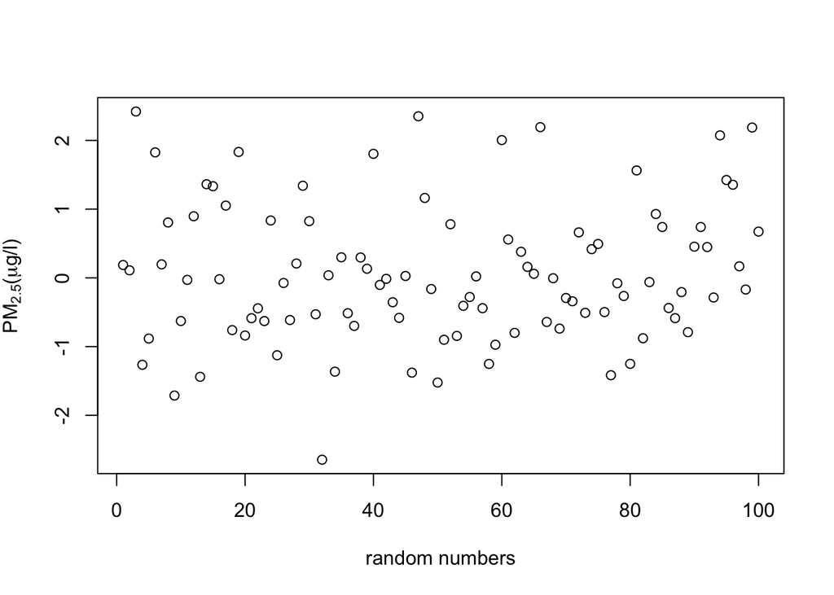

```r
library(latex2exp)
x <- rnorm(100)
plot(x, xlab = "random numbers", ylab = TeX('$PM_{2.5}(\\mu g/l)$'))
```